# Data Science for Bioinformatics - Week 04

Thomas Bataillon

September 13, 2018

### ABD book readings

Read through chapter 6 and 7. Lecture tuesday will be on testing a null hypothesis, what is a p-value, with concrete examples from the book.

### R for data science readings

Either you can do all the exercises in this document (to save your answers) or a new one.

The tutorial is from the free book “R for data science” written by the R Overlord Hadley Wickham

URL: http://r4ds.had.co.nz/index.html

- Go through 6. Workflow : scripts (this should be quick as you know the R studio env)
- Go through 7. Exploratory Data Analysis  
  try exercises in the chapter 6 & 7

#### Work on the mammals dataset (resuming the work we started in week 3)

We will work (again) on the data from Nguyen L-P, Galtier N, Nabholz B. 2015 Gene expression, chromosome heterogeneity and the fast-X effect in mammals. Biol. Lett.11 : 20150010.

In week 2 you have made some basic visual displays of a fraction of the data (the RPKM variable), producing histogram for each species.

Here we continue to work on this dataset and the goal of this R session is to dig deeper in the data vizualization and the data analysis of the paper.

More specifically 2 main goals of this session are :

- To reproduce the Figure 1 of the paper
- To use binomial tests for proportions to test if the genes sitting on X chromosome have atypical patterns of gene expression ( as measured by RPKM) and gene evolution (as measured by dn/ds). Note that these tests are not made as such in the paper where they rely instead on a global linear model (we will come to that in a few weeks, patience ;-))

# Loading the data

```r
library(tidyverse)
mammals = read_csv(file = "../datasets/dataset.01.rsbl20150010supp1.csv")
```

# Gene expression and its pattern of covariation with dn/ds in the mammals dataset.

## Q1: Create a new dataset that contains means per chromosome of dn/ds and log10(RPKM+1)

Recall that we did a new variable called “expression” that is the log10(RPKM+1)

Hint: adapt the code you used when obtaining the mean, median and standard deviation of the expression for each Species.

```r
mam_mut = mammals %>% group_by(chr, Species, chrMark) %>% summarise(mean_dnds = mean(dNdS), expr = mean(log10(RPKM + 1)))
```

## Q2: Reproduce the figure 1 of the paper where the covariation between dN/dS and RPKM is visualized.

Hint: geom_smooth() can be used in ggplot to add regression lines (lookup/ resuse examples of the r for data science book)

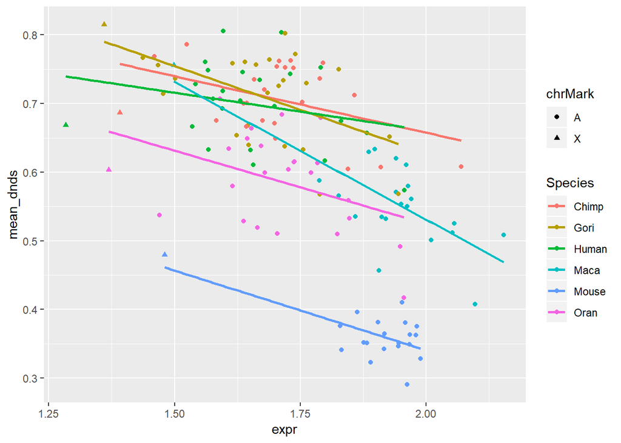

```r
ggplot(mam_mut) + geom_point(mapping = aes(x = expr, y = mean_dnds, color = Species, shape = chrMark)) +
  geom_smooth(mapping = aes(x = expr, y = mean_dnds, color = Species), se = FALSE, method = 'lm')
```

## Q3: Are genes on the X more often lowly expressed ? For each species in the dataset:

- Calculate the number (and proportion) of genes that are in the lower 15% range of gene expression for each chromosome. Note that the 15% cutoff value you should use is species specific.

```r
mammals2 = mammals %>%
  group_by(chr,Species) %>%
  mutate(all_n = n(), expr = log10(RPKM + 1), cutoff = quantile(expr, .15)) %>%
  filter(expr < cutoff) %>%
  summarise(count = length(expr), prop = mean(n()/all_n), all_n = mean(all_n))
```

- test if the X chromosome has a higher proportion of genes in the lower 15% of expression relative to the rest of the genome. Hint. Adapt the book ABD example of the binomial test for a proportion (Example 7.2 Sex and the X).

```r
# total x chr: 382
# x chr under 15% : 58
mammals %>%
  group_by(chr) %>%
  mutate(total = n(), expr = log10(RPKM + 1), cutoff = quantile(expr, .15)) %>%
  filter(expr < cutoff, chr == 'X') %>%
  summarise(count = length(expr), total = mean(total))
```

```
## # A tibble: 1 x 3
##   chr   count total
##   <chr> <int> <dbl>
## 1 X        58   382
```

```r
#prob under X:
mammals %>%
  group_by(chr) %>%
  mutate(total = n(), expr = log10(RPKM + 1), cutoff = quantile(expr, .15)) %>%
  filter(expr < cutoff, chr != 'X') %>%
  summarise(mean_prop = (mean(n()/total))) %>% summarise(mean_overall = mean(mean_prop))
```

```
## # A tibble: 1 x 1
##   mean_overall
##          <dbl>
## 1        0.151
```

```r
binom.test(58, 382, 0.151, alternative = "greater")
```

```
##
##  Exact binomial test
##
## data:  58 and 382
## number of successes = 58, number of trials = 382, p-value = 0.5037
## alternative hypothesis: true probability of success is greater than 0.151
## 95 percent confidence interval:
##  0.1224117 1.0000000
## sample estimates:
## probability of success
##              0.1518325
```

- Try a different cutoff for “low gene expression” (say 5%), and examine how sample size, difference between X vs rest and p values are affected by the change of threshold.

```r
# total x chr: 382
# x chr under 5% : 20
mammals %>%
  group_by(chr) %>%
  mutate(total = n(), expr = log10(RPKM + 1), cutoff = quantile(expr, .05)) %>%
  filter(expr < cutoff, chr == 'X') %>%
  summarise(count = length(expr), total = mean(total))
```

```
## # A tibble: 1 x 3
##   chr   count total
##   <chr> <int> <dbl>
## 1 X        20   382
```

```r
#prob under X:
mammals %>%
  group_by(chr) %>%
  mutate(total = n(), expr = log10(RPKM + 1), cutoff = quantile(expr, .05)) %>%
  filter(expr < cutoff, chr != 'X') %>%
  summarise(mean_prop = (mean(n()/total))) %>% summarise(mean_overall = mean(mean_prop))
```

```
## # A tibble: 1 x 1
##   mean_overall
##          <dbl>
## 1       0.0513
```

```r
binom.test(20, 382, 0.0513, alternative = "greater")
```

```
##
##  Exact binomial test
##
## data:  20 and 382
## number of successes = 20, number of trials = 382, p-value = 0.495
## alternative hypothesis: true probability of success is greater than 0.0513
## 95 percent confidence interval:
##  0.03496404 1.00000000
## sample estimates:
## probability of success
##             0.05235602
```

p-value of 0.495

- bonus question: if we restrict ourselves to subset of the (15%) low expression genes, what proportion of these genes have a high dn/ds (use the quantiles of the dn/ds distribution to decide on a cutoff), and is this proportion significantly different between autosomes and the X ?